# 🔶 Nível de Significância (ALPHA ou α)

O nível de significância é um valor arbitrário (ou seja, escolhido por nós) que definimos antes do estudo. A grosso modo, é a probabilidade de você dizer que há um efeito quando não há efeito.

Níveis de significância mais baixos indicam que você precisa de evidências mais substanciais antes de rejeitar o nulo — ou seja, quanto menor o alpha, mais dificilmente você rejeita a hipótese nula.

📌 Exemplo: um nível de significância de 0,05 significa um risco de 5% de decidir que existe um efeito quando não existe.

# 🎯 Como entender isso na prática

Seus dados fornecem evidências de um efeito (por exemplo, diferença no tempo de recuperação entre pacientes que tomaram o novo medicamento e os que tomaram placebo). O nível de significância é uma medida de quão forte a evidência da amostra deve ser antes de determinarmos se os resultados são estatisticamente significativos.

Ele define a linha entre:

- Evidência forte o suficiente para concluir que o efeito existe na população
- Evidência fraca, ou seja, não podemos descartar que o efeito amostral seja apenas erro aleatório

# ✅ Pensando no caso jurídico

Vamos fazer um paralelo com casos judiciais para entender melhor o conceito de nível de significância.

Casos civis e casos criminais exigem quantidades diferentes de evidência para convencer um juiz ou júri. Em casos civis, como disputas contratuais ou indenizações, muitos estudiosos sugerem que 51% das provas apresentadas já são suficientes para uma decisão — ou seja, basta que seja mais provável que não que o réu tenha responsabilidade.

Por outro lado, casos criminais, que envolvem consequências mais sérias (como perda de liberdade), exigem muito mais evidência. A maioria dos especialistas considera aceitável somente quando há 90%, 95% ou até 99% de certeza de que o réu é culpado.

👉 Esse grau de certeza pode ser comparado ao nível de significância nos testes estatísticos.

# ⚡ Uma analogia com a área da saúde

Vamos pensar em dois contextos da saúde:

- Casos simples: como avaliar se um remédio genérico tem o mesmo efeito que o original em uma dor leve. Talvez um pequeno nível de evidência (como 90% de certeza) seja suficiente para você prescrever o genérico.
- Casos graves: como decidir se um novo tratamento para câncer é mais eficaz. Aqui, os riscos de um erro são maiores — por isso, exigimos níveis de certeza mais altos, como 99%, antes de aceitar o novo tratamento.

Assim como o "nível de certeza" varia conforme o risco clínico, o nível de significância (alpha) pode ser ajustado:

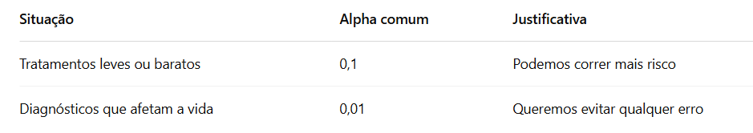

Assim como o "nível de certeza" varia com a gravidade do caso jurídico, o nível de significância (α) pode e deve ser ajustado conforme as consequências do erro na sua análise estatística:

- Menor alpha (ex: 0,01) → exige mais provas, mais confiança para rejeitar H0 (semelhante a um julgamento criminal).
- Maior alpha (ex: 0,10) → exige menos provas, maior risco de erro tipo I (semelhante a um julgamento civil).

📌 O valor 0,05 é o padrão na maioria dos estudos, mas, assim como nos tribunais, você pode e deve ajustar esse padrão de acordo com o risco do erro e o impacto da decisão.

# 📈 Visualizando o nível de significância

📉 O nível de significância define o quão longe o valor da amostra deve estar para que possamos rejeitar a hipótese nula.

A área sombreada sob a curva representa o quanto estamos dispostos a aceitar que um resultado raro (se a hipótese nula for verdadeira) ainda assim aconteça por acaso.

No exemplo acima, temos um alpha de 0,1, então 10% da curva está sombreada (5% de cada lado).

Isso define a região de rejeição da hipótese nula.

Se nosso valor amostral cair ali, dizemos que está estatisticamente longe demais para ser compatível com a hipótese nula.

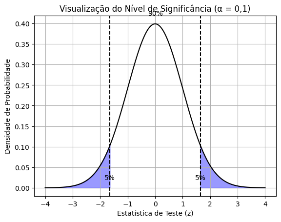

```python
import numpy as np
import matplotlib.pyplot as plt
from scipy.stats import norm

# Parâmetros
media_hipotese_nula = 0
desvio_padrao = 1
alpha = 0.1  # nível de significância total (5% para cada lado)
z_critico = norm.ppf(1 - alpha / 2)  # valor crítico para região de rejeição bilateral

# Geração dos dados da curva normal
x = np.linspace(-4, 4, 1000)
y = norm.pdf(x, media_hipotese_nula, desvio_padrao)

# Plot da curva normal
plt.plot(x, y, color='black')

# Preenchendo as regiões críticas
x_rejeita_esquerda = np.linspace(-4, -z_critico, 100)
y_rejeita_esquerda = norm.pdf(x_rejeita_esquerda, media_hipotese_nula, desvio_padrao)
plt.fill_between(x_rejeita_esquerda, y_rejeita_esquerda, color='blue', alpha=0.4)

x_rejeita_direita = np.linspace(z_critico, 4, 100)
y_rejeita_direita = norm.pdf(x_rejeita_direita, media_hipotese_nula, desvio_padrao)
plt.fill_between(x_rejeita_direita, y_rejeita_direita, color='blue', alpha=0.4)

# Anotações
plt.text(-z_critico, 0.02, '5%', ha='center')
plt.text(z_critico, 0.02, '5%', ha='center')
plt.text(0, 0.42, '90%', ha='center')
plt.axvline(x=-z_critico, color='black', linestyle='dashed')
plt.axvline(x=z_critico, color='black', linestyle='dashed')

# Títulos e rótulos
plt.title('Visualização do Nível de Significância (α = 0,1)')
plt.xlabel('Estatística de Teste (z)')
plt.ylabel('Densidade de Probabilidade')

# Exibir gráfico
plt.grid(True)
plt.show()
```

Aqui está o gráfico que representa visualmente o nível de significância α = 0,1 em um teste bicaudal:

- As áreas azuis representam as regiões críticas de rejeição da hipótese nula (H₀).
- Cada região crítica tem 5% da área total da distribuição (α/2).
- A área central (entre os dois limites críticos) representa os 90% de confiança, onde não rejeitamos H₀.

Se a estatística de teste (z) calculada cair em qualquer uma das áreas sombreadas, rejeitamos H₀ com 10% de significância. Caso contrário, não rejeitamos H₀. Isso é usado, por exemplo, para verificar se uma média observada está "longe o suficiente" da média sob a hipótese nula.